# PA1_template

Monica Oves

January 30, 2018

# Analysis of Personal Movement using Activity Monitoring Devices

# Synopsis:

It is now possible to collect a large amount of data about personal movement using activity monitoring devices such as a Fitbit, Nike Fuelband, or Jawbone Up. These type of devices are part of the “quantified self” movement  a group of enthusiasts who take measurements about themselves regularly to improve their health, to find patterns in their behavior, or because they are tech geeks. But these data remain under-utilized both because the raw data are hard to obtain and there is a lack of statistical methods and software for processing and interpreting the data. This code makes use of data from a personal activity monitoring device by analyzing total steps, average steps in five minute intervals, as well as compared activity levels between weekdays and weekends. This device collects data at 5 minute intervals through out the day. The data consists of two months of data from an anonymous individual collected during the months of October and November, 2012 and include the number of steps taken in 5 minute intervals each day.

# Data Processing:

I manually set the working directory The code refining and checking/processing the data in the format that I need

```r
setwd("~/Monica/DataScience/ReproducibleResearch/repdata%2Fdata%2Factivity")
activitydata <- read.csv("activity.csv", header=TRUE, sep = ",", na.strings = "NA")
summary(activitydata)
```

```
##      steps                date          interval
##  Min.   :  0.00   2012-10-01:  288   Min.   :   0.0
##  1st Qu.:  0.00   2012-10-02:  288   1st Qu.: 588.8
##  Median :  0.00   2012-10-03:  288   Median :1177.5
##  Mean   : 37.38   2012-10-04:  288   Mean   :1177.5
##  3rd Qu.: 12.00   2012-10-05:  288   3rd Qu.:1766.2
##  Max.   :806.00   2012-10-06:  288   Max.   :2355.0
##  NA's   :2304     (Other)   :15840
```

```r
activitydata$date <- as.Date(activitydata$date, format = "%Y-%m-%d")
activitydata$interval <- factor(activitydata$interval)
```

### The total number of steps taken is summed up

```r
setwd("~/Monica/DataScience/ReproducibleResearch/repdata%2Fdata%2Factivity")
NAs <- is.na(as.character(activitydata$steps))
activitydata_noNA <- activitydata[!NAs,]
head(activitydata_noNA)
```

```
##     steps       date interval
## 289     0 2012-10-02        0
## 290     0 2012-10-02        5
## 291     0 2012-10-02       10
## 292     0 2012-10-02       15
## 293     0 2012-10-02       20
## 294     0 2012-10-02       25
```

```r
dailysteps <- aggregate(steps ~ date, data = activitydata_noNA, sum)
colnames(dailysteps) <- c("date", "steps")
```

### A histogram of the total number of steps taken each day

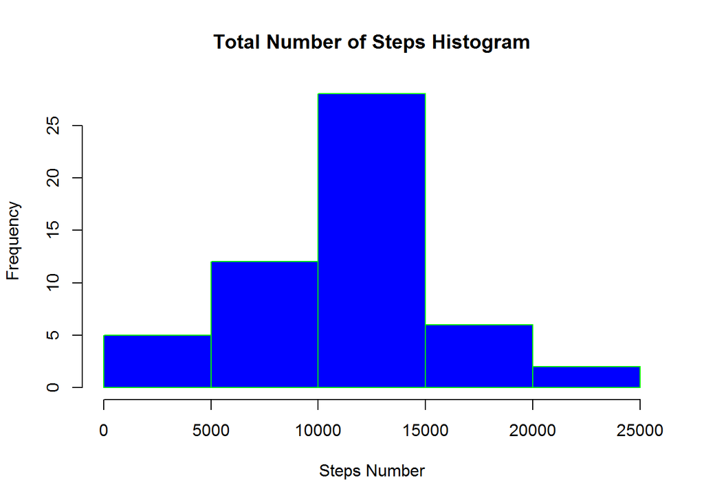

```r
setwd("~/Monica/DataScience/ReproducibleResearch/repdata%2Fdata%2Factivity")
hist(as.numeric(dailysteps$steps), col = "blue", border = "green", xlab = "Steps Number", ylab = "Frequency", main = "Total Number of Steps Histogram")
```

### Mean and median are calculated

```r
setwd("~/Monica/DataScience/ReproducibleResearch/repdata%2Fdata%2Factivity")
mean(dailysteps$steps)
```

```
## [1] 10766.19
```

```r
median(dailysteps$steps)
```

```
## [1] 10765
```

### The average daily activity pattern is calculated in five minute intervals, and then a time plot of average number of steps taken is plotted

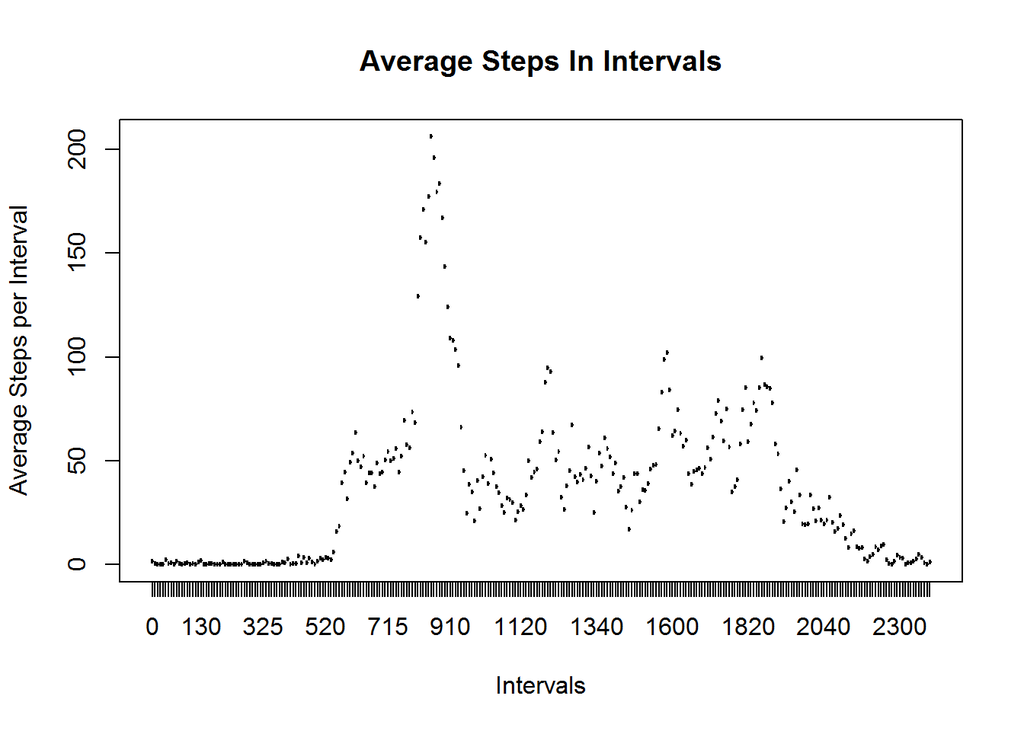

```r
setwd("~/Monica/DataScience/ReproducibleResearch/repdata%2Fdata%2Factivity")
averageintervalsteps <- aggregate(steps ~ interval, data = activitydata_noNA, mean, na.rm = TRUE)
colnames(averageintervalsteps) <- c("interval", "steps")

plot(steps ~ interval, data = averageintervalsteps, type = "l", xlab = "Intervals", ylab = "Average Steps per Interval", main = "Average Steps In Intervals", col = "red")
```

### The maximum number of average steps in a five minute interval

```r
setwd("~/Monica/DataScience/ReproducibleResearch/repdata%2Fdata%2Factivity")
stepsmax <- max(averageintervalsteps$steps)
intervalmaxsteps <- averageintervalsteps[which.max(averageintervalsteps$steps),]$interval
intervalmaxsteps
```

```
## [1] 835
## 288 Levels: 0 5 10 15 20 25 30 35 40 45 50 55 100 105 110 115 120 ... 2355
```

### Find the missing values, and impute the missing values with the mean of five minute intervals

```r
setwd("~/Monica/DataScience/ReproducibleResearch/repdata%2Fdata%2Factivity")
sum(is.na(as.character(activitydata$steps)))
```

```
## [1] 2304
```

```r
sum(is.na(as.character(activitydata$date)))
```

```
## [1] 0
```

```r
sum(is.na(as.character(activitydata$interval)))
```

```
## [1] 0
```

```r
NAs <- which(is.na(as.character(activitydata$steps)))

meansteps <- function(interval){
  averageintervalsteps[averageintervalsteps$interval==interval, "steps"]
}
allactivitydata <- activitydata
values = 0
for (i in 1:nrow(allactivitydata)) {
  if (is.na(allactivitydata[i, "steps"])) {
    allactivitydata[i,"steps"] <- meansteps(allactivitydata[i, "interval"])
    values = values + 1
  }
}
summary(allactivitydata)
```

```
##      steps             date               interval
##  Min.   :  0.00   Min.   :2012-10-01   0      :   61
##  1st Qu.:  0.00   1st Qu.:2012-10-16   5      :   61
##  Median :  0.00   Median :2012-10-31   10     :   61
##  Mean   : 37.38   Mean   :2012-10-31   15     :   61
##  3rd Qu.: 27.00   3rd Qu.:2012-11-15   20     :   61
##  Max.   :806.00   Max.   :2012-11-30   25     :   61
##                                        (Other):17202
```

```r
str(allactivitydata)
```

```
## 'data.frame':    17568 obs. of  3 variables:
##  $ steps   : num  1.717 0.3396 0.1321 0.1509 0.0755 ...
##  $ date    : Date, format: "2012-10-01" "2012-10-01" ...
##  $ interval: Factor w/ 288 levels "0","5","10","15",..: 1 2 3 4 5 6 7 8 9 10 ...
```